# AllLife Bank Customer Segmentation

## Context

AllLife Bank wants to focus on its credit card customer base in the next financial year. They have been advised by their marketing research team, that the penetration in the market can be improved. Based on this input, the Marketing team proposes to run personalized campaigns to target new customers as well as upsell to existing customers. Another insight from the market research was that the customers perceive the support services of the back poorly. Based on this, the Operations team wants to upgrade the service delivery model, to ensure that customer queries are resolved faster. Head of Marketing and Head of Delivery both decide to reach out to the Data Science team for help.

## Objective

To identify different segments in the existing customer, based on their spending patterns as well as past interaction with the bank, using clustering algorithms, and provide recommendations to the bank on how to better market to and service these customers.

### Data Description

The data provided is of various customers of a bank and their financial attributes like credit limit, the total number of credit cards the customer has, and different channels through which customers have contacted the bank for any queries (including visiting the bank, online and through a call center).

**Data Dictionary**

- Sl_No: Primary key of the records
- Customer Key: Customer identification number
- Average Credit Limit: Average credit limit of each customer for all credit cards
- Total credit cards: Total number of credit cards possessed by the customer
- Total visits bank: Total number of visits that customer made (yearly) personally to the bank
- Total visits online: Total number of visits or online logins made by the customer (yearly)
- Total calls made: Total number of calls made by the customer to the bank or its customer service department (yearly)

### Importing necessary libraries

```python
# Libraries to help with reading and manipulating data
import numpy as np
import pandas as pd

# Libraries to help with data visualization
import matplotlib.pyplot as plt
import seaborn as sns

# Removes the limit for the number of displayed columns
pd.set_option("display.max_columns", None)
# Sets the limit for the number of displayed rows
pd.set_option("display.max_rows", 200)

# to scale the data using z-score
from sklearn.preprocessing import StandardScaler

# to compute distances
from scipy.spatial.distance import pdist

# to perform hierarchical clustering, compute cophenetic correlation, and create dendrograms
from sklearn.cluster import AgglomerativeClustering
from scipy.cluster.hierarchy import dendrogram, linkage, cophenet

# to perform PCA
from sklearn.decomposition import PCA

import warnings
warnings.filterwarnings("ignore")
```

### Read the dataset

```python
# loading the dataset
data = pd.read_csv("Credit_Card_Customer_Data.csv")
```

### View the random 10 rows of the dataset.

```python
# viewing a random sample of the dataset
data.sample(n=10, random_state=1)
```

|  | Sl_No | Customer Key | Avg_Credit_Limit | Total_Credit_Cards | Total_visits_bank | Total_visits_online | Total_calls_made |
| --- | --- | --- | --- | --- | --- | --- | --- |
| 547 | 548 | 38125 | 26000 | 4 | 5 | 2 | 4 |
| 353 | 354 | 94437 | 9000 | 5 | 4 | 1 | 3 |
| 499 | 500 | 65825 | 68000 | 6 | 4 | 2 | 2 |
| 173 | 174 | 38410 | 9000 | 2 | 1 | 5 | 8 |
| 241 | 242 | 81878 | 10000 | 4 | 5 | 1 | 3 |
| 341 | 342 | 70779 | 18000 | 4 | 3 | 2 | 0 |
| 647 | 648 | 79953 | 183000 | 9 | 0 | 9 | 2 |
| 218 | 219 | 28208 | 19000 | 3 | 1 | 5 | 7 |
| 120 | 121 | 16577 | 10000 | 4 | 2 | 4 | 6 |
| 134 | 135 | 31256 | 13000 | 4 | 1 | 5 | 7 |

```python
data.shape
```

```
(660, 7)
```

- The dataset has 660 rows and 7 columns

```python
# copying the data to another variable to avoid any changes to original data
df1 = data.copy()
```

```python
#find duplicate rows across all columns
duplicateRows_last = df1[df1.duplicated(keep='last')]
duplicateRows_last
```

|  | Sl_No | Customer Key | Avg_Credit_Limit | Total_Credit_Cards | Total_visits_bank | Total_visits_online | Total_calls_made |
| --- | --- | --- | --- | --- | --- | --- | --- |

- There are no duplicated rows

```python
# Drop Serial no and customer key nos.
df1.drop(columns = ['Sl_No','Customer Key'],inplace=True)
```

### Check the data types of the columns for the dataset.

```python
# checking datatypes and number of non-null values for each column
df1.info()
```

```
<class 'pandas.core.frame.DataFrame'>
RangeIndex: 660 entries, 0 to 659
Data columns (total 5 columns):
 #   Column               Non-Null Count  Dtype
---  ------               --------------  -----
 0   Avg_Credit_Limit     660 non-null    int64
 1   Total_Credit_Cards   660 non-null    int64
 2   Total_visits_bank    660 non-null    int64
 3   Total_visits_online  660 non-null    int64
 4   Total_calls_made     660 non-null    int64
dtypes: int64(5)
memory usage: 25.9 KB
```

**Observations**

- All are numeric variables with no missing values.

### Summary of the dataset.

```python
# Let's look at the statistical summary of the data
df1.describe(include="all").T### Summary of the dataset.
```

|  | count | mean | std | min | 25% | 50% | 75% | max |
| --- | --- | --- | --- | --- | --- | --- | --- | --- |
| Avg_Credit_Limit | 660.0 | 34574.242424 | 37625.487804 | 3000.0 | 10000.0 | 18000.0 | 48000.0 | 200000.0 |
| Total_Credit_Cards | 660.0 | 4.706061 | 2.167835 | 1.0 | 3.0 | 5.0 | 6.0 | 10.0 |
| Total_visits_bank | 660.0 | 2.403030 | 1.631813 | 0.0 | 1.0 | 2.0 | 4.0 | 5.0 |
| Total_visits_online | 660.0 | 2.606061 | 2.935724 | 0.0 | 1.0 | 2.0 | 4.0 | 15.0 |
| Total_calls_made | 660.0 | 3.583333 | 2.865317 | 0.0 | 1.0 | 3.0 | 5.0 | 10.0 |

###### **Observations**

- There are 660 rows in the data.
- Data consist of average credit limit, total credit cards, total visit to banks or online and total calls made.
- Average credit limit and online visits seem to have outlier which would be improved through log normal distribution.

## EDA

### Univariate Analysis

```python
# function to create labeled barplots


def labeled_barplot(data, feature, perc=False, n=None):
    """
    Barplot with percentage at the top

    data: dataframe
    feature: dataframe column
    perc: whether to display percentages instead of count (default is False)
    n: displays the top n category levels (default is None, i.e., display all levels)
    """

    total = len(data[feature])  # length of the column
    count = data[feature].nunique()
    if n is None:
        plt.figure(figsize=(count + 1, 5))
    else:
        plt.figure(figsize=(n + 1, 5))

    plt.xticks(rotation=90, fontsize=15)
    ax = sns.countplot(
        data=data,
        x=feature,
        palette="Paired",
        order=data[feature].value_counts().index[:n].sort_values(),
    )

    for p in ax.patches:
        if perc == True:
            label = "{:.1f}%".format(
                100 * p.get_height() / total
            )  # percentage of each class of the category
        else:
            label = p.get_height()  # count of each level of the category

        x = p.get_x() + p.get_width() / 2  # width of the plot
        y = p.get_height()  # height of the plot

        ax.annotate(
            label,
            (x, y),
            ha="center",
            va="center",
            size=12,
            xytext=(0, 5),
            textcoords="offset points",
        )  # annotate the percentage

    plt.show()  # show the plot
```

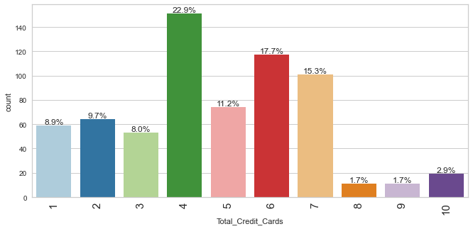

```python
labeled_barplot(df1, "Total_Credit_Cards", perc=True)
```

**Observations**

- Approx. 23% of the customers have 4 credit card , followed by 18% having 6 & 15% having 7.
- Customers having 8+ cards have very less distribution.

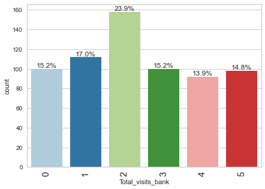

```python
labeled_barplot(df1, "Total_visits_bank", perc=True)
```

**Observations**

- Approximate 24% customers have made visits to the banks 2 time yearly.

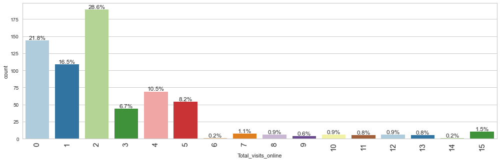

```python
labeled_barplot(df1, "Total_visits_online", perc=True)
```

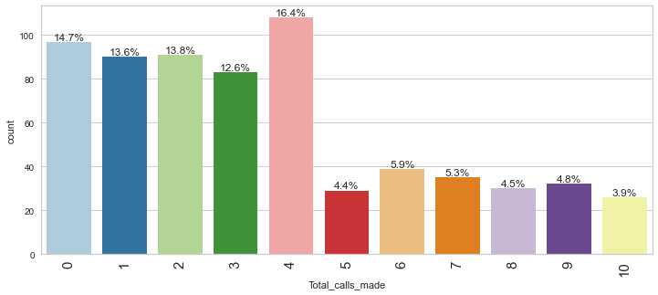

```python
labeled_barplot(df1, "Total_calls_made", perc=True)
```

```python
# function to plot a boxplot and a histogram along the same scale.


def histogram_boxplot(data, feature, figsize=(12, 7), kde=False, bins=None):
    """
    Boxplot and histogram combined

    data: dataframe
    feature: dataframe column
    figsize: size of figure (default (12,7))
    kde: whether to the show density curve (default False)
    bins: number of bins for histogram (default None)
    """
    f2, (ax_box2, ax_hist2) = plt.subplots(
        nrows=2,  # Number of rows of the subplot grid= 2
        sharex=True,  # x-axis will be shared among all subplots
        gridspec_kw={"height_ratios": (0.25, 0.75)},
        figsize=figsize,
    )  # creating the 2 subplots
    sns.boxplot(
        data=data, x=feature, ax=ax_box2, showmeans=True, color="violet"
    )  # boxplot will be created and a star will indicate the mean value of the column
    sns.histplot(
        data=data, x=feature, kde=kde, ax=ax_hist2, bins=bins, palette="winter"
    ) if bins else sns.histplot(
        data=data, x=feature, kde=kde, ax=ax_hist2
    )  # For histogram
    ax_hist2.axvline(
        data[feature].mean(), color="green", linestyle="--"
    )  # Add mean to the histogram
    ax_hist2.axvline(
        data[feature].median(), color="black", linestyle="-"
    )  # Add median to the histogram
```

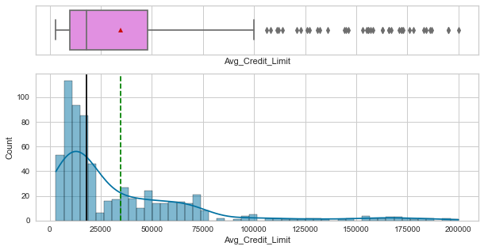

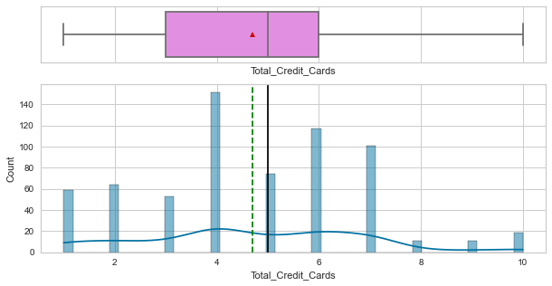

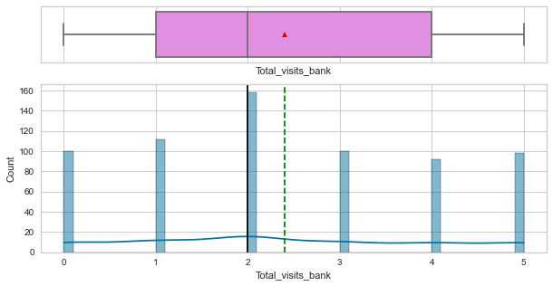

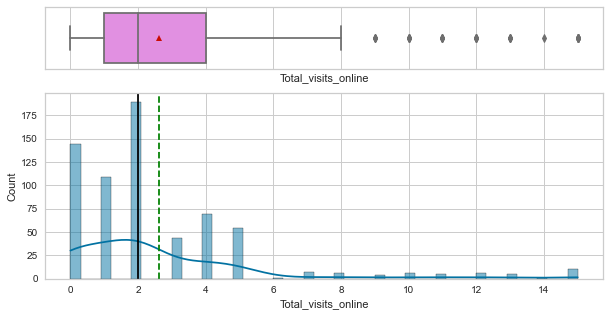

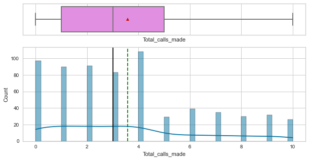

```python
# selecting numerical columns
num_cols = df1.select_dtypes(include=np.number).columns.tolist()

for item in num_cols:
    histogram_boxplot(df1, item, bins=50, kde=True, figsize=(10, 5))
```

**Observations**

- Variables like *Average Credit Limit*, *Total Visits Online*, are right-skewed and have upper outliers.

### Let's apply log normal distribution to average credit card

- Total_visit_online is not used for outlier treatment as it consist of discrete value and has higher frequency at "0" which should not be removed for log normal treatment.

```python
for column in [
    "Avg_Credit_Limit",
]:
    try:
        df1[column] = np.log10(df1[column])
    except (ValueError, AttributeError):
        pass
```

### Bivariate Analysis

**Let's check for correlations.**

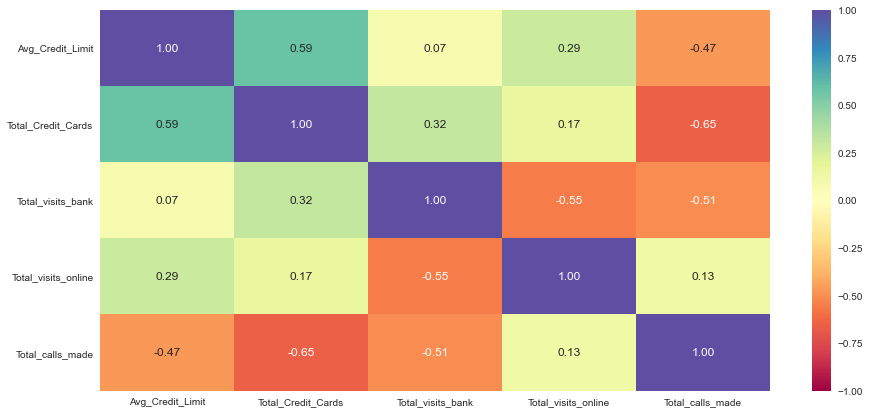

```python
plt.figure(figsize=(15, 7))
sns.heatmap(
    df1[num_cols].corr(), annot=True, vmin=-1, vmax=1, fmt=".2f", cmap="Spectral"
)
plt.show()
```

**Observations**

- Average credit limit & total credit cards have positive correlation
- Total calls made have stron negative correlation with avg credit limit & total credit cards.

## Data Preprocessing

### Checking for Null Values

```python
# checking for missing values

df1.isnull().sum()
```

```
Avg_Credit_Limit       0
Total_Credit_Cards     0
Total_visits_bank      0
Total_visits_online    0
Total_calls_made       0
dtype: int64
```

### **Let's scale the data for feature scaling.**

```python
sc = StandardScaler()
subset_scaled_df = pd.DataFrame(sc.fit_transform(df1))
subset_scaled_df.head()
```

|  | 0 | 1 | 2 | 3 | 4 |
| --- | --- | --- | --- | --- | --- |
| 0 | 1.630478 | -1.249225 | -0.860451 | -0.547490 | -1.251537 |
| 1 | 0.885387 | -0.787585 | -1.473731 | 2.520519 | 1.891859 |
| 2 | 0.885387 | 1.058973 | -0.860451 | 0.134290 | 0.145528 |
| 3 | 0.336281 | 0.135694 | -0.860451 | -0.547490 | 0.145528 |
| 4 | 1.630478 | 0.597334 | -1.473731 | 3.202298 | -0.203739 |

## Group Data into similar clusters

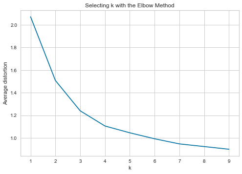

```python
from sklearn.cluster import KMeans
#Finding optimal no. of clusters
from scipy.spatial.distance import cdist
clusters=range(1,10)
meanDistortions=[]

for k in clusters:
    model=KMeans(n_clusters=k)
    model.fit(subset_scaled_df)
    prediction=model.predict(subset_scaled_df)
    meanDistortions.append(sum(np.min(cdist(subset_scaled_df, model.cluster_centers_, 'euclidean'), axis=1)) / subset_scaled_df.shape[0])

plt.plot(clusters, meanDistortions, 'bx-')
plt.xlabel('k')
plt.ylabel('Average distortion')
plt.title('Selecting k with the Elbow Method')
```

**In the above plot, the elbow is seen for K=2 and 4 but if you observe the Average distortion results, there is some drop in distortion at K= 5**

**To make a better decision about the number of clusters, we can look at the silhouette score for different K values.**

```
For n_clusters = 2, silhouette score is 0.4092836475058832
For n_clusters = 3, silhouette score is 0.49300104499954217
For n_clusters = 4, silhouette score is 0.38490703375801383
For n_clusters = 5, silhouette score is 0.3492698891789254
For n_clusters = 6, silhouette score is 0.2605065292630394
For n_clusters = 7, silhouette score is 0.26323975215927664
For n_clusters = 8, silhouette score is 0.2463657675692754
For n_clusters = 9, silhouette score is 0.23553925715891905
```

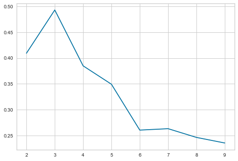

```python
from sklearn.metrics import silhouette_score

# to visualize the elbow curve and silhouette scores
from yellowbrick.cluster import KElbowVisualizer, SilhouetteVisualizer

sil_score = []  # Create empty list
cluster_list = list(range(2, 10))  # Creating a list of range from 2 to 10
for n_clusters in cluster_list:
    clusterer = KMeans(n_clusters=n_clusters)  # Initializing KMeans algorithm
    preds = clusterer.fit_predict((subset_scaled_df))  # Predicting on the data
    # centers = clusterer.cluster_centers_
    score = silhouette_score(subset_scaled_df, preds)  # Cacalculating silhouette score
    sil_score.append(score)  # Appending silhouette score to empty list created above
    print("For n_clusters = {}, silhouette score is {}".format(n_clusters, score))

plt.plot(cluster_list, sil_score)
```

**From the silhouette scores, it seems that 3 is a good value of k. Let's check with SilhouetteVisualizer with different k values**

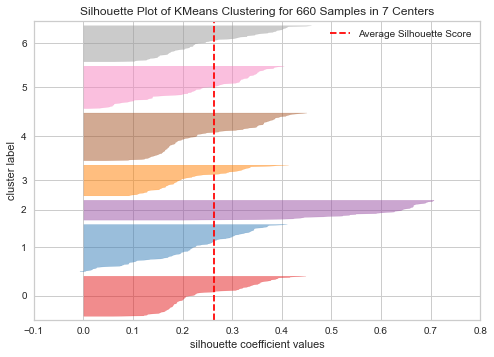

```python
# finding optimal no. of clusters with silhouette coefficients
visualizer = SilhouetteVisualizer(KMeans(7, random_state=1))
visualizer.fit(subset_scaled_df)
visualizer.show()
```

**k=7 meets criteria that all silhouetee score greater than average but width of some clusters like 0&6 , 4&5 is roughly same. let's explore more k values.**

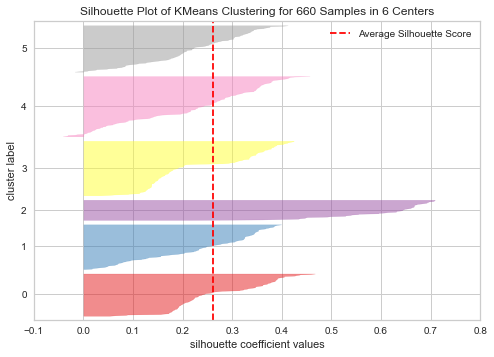

```python
# finding optimal no. of clusters with silhouette coefficients
visualizer = SilhouetteVisualizer(KMeans(6, random_state=1))
visualizer.fit(subset_scaled_df)
visualizer.show()
```

**Same issue as some of the cluster width is same. Also there is no knee so we should focus on k=2,3,4**

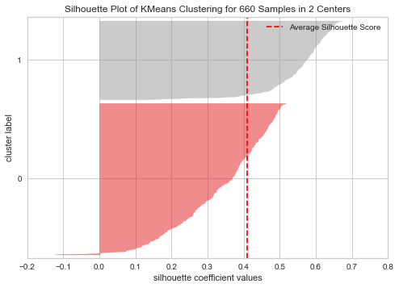

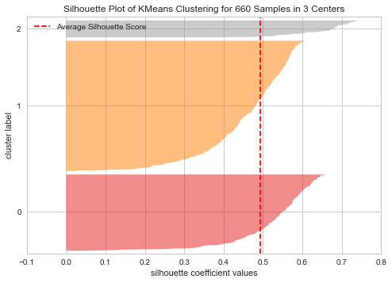

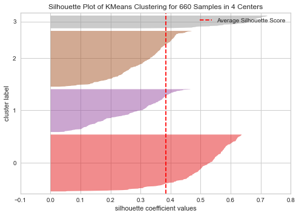

```python
# finding optimal no. of clusters with silhouette coefficients
for k_val in range(2,5):
    visualizer = SilhouetteVisualizer(KMeans(k_val, random_state=1))
    visualizer.fit(subset_scaled_df)
    visualizer.show()
```

**k=3 looks best and meet all criteria related to width & all clusters greater than average. Let's use this for cluster profiling**

```python
kmeans = KMeans(n_clusters=3, random_state=0)
kmeans.fit(subset_scaled_df)
# adding kmeans cluster labels to the original dataframe
df1["K_means_segments"] = kmeans.labels_
cluster_profile = df1.groupby("K_means_segments").mean()
cluster_profile["count_in_each_segment"] = (
    df1.groupby("K_means_segments")["Avg_Credit_Limit"].count().values
)
# let's display cluster profiles
cluster_profile.style.highlight_max(color="lightgreen", axis=0)
```

| K_means_segments | Avg_Credit_Limit | Total_Credit_Cards | Total_visits_bank | Total_visits_online | Total_calls_made | count_in_each_segment |
| --- | --- | --- | --- | --- | --- | --- |
| 0 | 5.135755 | 8.740000 | 0.600000 | 10.900000 | 1.080000 | 50 |
| 1 | 4.045924 | 2.422222 | 0.937778 | 3.546667 | 6.857778 | 225 |
| 2 | 4.410674 | 5.516883 | 3.493506 | 0.979221 | 1.994805 | 385 |

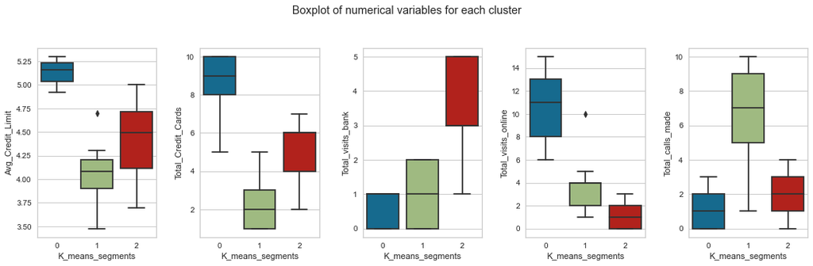

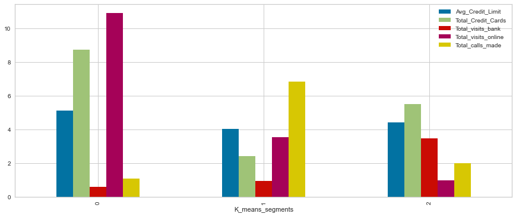

```python
fig, axes = plt.subplots(1, 5, figsize=(15, 5))
fig.suptitle("Boxplot of numerical variables for each cluster")
counter = 0
num_col = df1.select_dtypes(include=np.number).columns.tolist()
for ii in range(5):
    sns.boxplot(ax=axes[ii], y=df1[num_col[counter]], x=df1["K_means_segments"])
    counter = counter + 1

fig.tight_layout(pad=2.0)

df1.groupby("K_means_segments").mean().plot.bar(figsize=(15, 6))
```

### Insights

- **Cluster 0**:
  - Average Credit Limit, total number of credit cards , visits online is high but low to banks. Calls made to bank is low suggesting they faced less issue.
- **Cluster 1**:
  - Average Credit Limit, total number of credit cards , visits online/bank is low to moderate . Calls made is higher.
- **Cluster 2**:
  - Average Credit Limit, total number of credit cards , visits bank is moderate but visit online is low . Calls made is low.

### Business Recommendations

- **Cluster 0**: These are tier 1 customers who are mostly well to do and tech savy. For bank, they are likely very good customers in terms of revenue generation and should have dedicated team to provide best service**
- **Cluster 1**: These are tier 2 customers with low usage. Bank should work on incentives to see how these groups can be incentivized for more usage**
- **Cluster 2**: These are tier 3 with moderate usage but their online presence is low. Bank should work on steps to increase their online presence and work on thei factors to see what mitigates their online use. This can possible lead to more revenue genration**

## Hierarchical Clustering

### Cophenetic correlation

```python
# Create fresh copy of dataframe
df1 = data.copy()

# Drop Serial no and customer key nos.
df1.drop(columns = ['Sl_No','Customer Key'],inplace=True)

sc = StandardScaler()
subset_scaled_df = pd.DataFrame(sc.fit_transform(df1))
subset_scaled_df.head()
```

|  | 0 | 1 | 2 | 3 | 4 |
| --- | --- | --- | --- | --- | --- |
| 0 | 1.740187 | -1.249225 | -0.860451 | -0.547490 | -1.251537 |
| 1 | 0.410293 | -0.787585 | -1.473731 | 2.520519 | 1.891859 |
| 2 | 0.410293 | 1.058973 | -0.860451 | 0.134290 | 0.145528 |
| 3 | -0.121665 | 0.135694 | -0.860451 | -0.547490 | 0.145528 |
| 4 | 1.740187 | 0.597334 | -1.473731 | 3.202298 | -0.203739 |

```python
# list of distance metrics
distance_metrics = ["euclidean", "chebyshev", "mahalanobis", "cityblock"]

# list of linkage methods
linkage_methods = ["single", "complete", "average", "weighted"]

high_cophenet_corr = 0
high_dm_lm = [0, 0]

for dm in distance_metrics:
    for lm in linkage_methods:
        Z = linkage(subset_scaled_df, metric=dm, method=lm)
        c, coph_dists = cophenet(Z, pdist(subset_scaled_df))
        print(
            "Cophenetic correlation for {} distance and {} linkage is {}.".format(
                dm.capitalize(), lm, c
            )
        )
        if high_cophenet_corr < c:
            high_cophenet_corr = c
            high_dm_lm[0] = dm
            high_dm_lm[1] = lm
```

```
Cophenetic correlation for Euclidean distance and single linkage is 0.7391220243806552.
Cophenetic correlation for Euclidean distance and complete linkage is 0.8599730607972423.
Cophenetic correlation for Euclidean distance and average linkage is 0.8977080867389372.
Cophenetic correlation for Euclidean distance and weighted linkage is 0.8861746814895477.
Cophenetic correlation for Chebyshev distance and single linkage is 0.7382354769296767.
Cophenetic correlation for Chebyshev distance and complete linkage is 0.8533474836336782.
Cophenetic correlation for Chebyshev distance and average linkage is 0.8974159511838106.
Cophenetic correlation for Chebyshev distance and weighted linkage is 0.8913624010768603.
Cophenetic correlation for Mahalanobis distance and single linkage is 0.7058064784553605.
Cophenetic correlation for Mahalanobis distance and complete linkage is 0.5422791209801746.
Cophenetic correlation for Mahalanobis distance and average linkage is 0.8326994115042134.
Cophenetic correlation for Mahalanobis distance and weighted linkage is 0.7805990615142518.
Cophenetic correlation for Cityblock distance and single linkage is 0.7252379350252723.
Cophenetic correlation for Cityblock distance and complete linkage is 0.8731477899179829.
Cophenetic correlation for Cityblock distance and average linkage is 0.896329431104133.
Cophenetic correlation for Cityblock distance and weighted linkage is 0.8825520731498188.
```

```python
# printing the combination of distance metric and linkage method with the highest cophenetic correlation
print(
    "Highest cophenetic correlation is {}, which is obtained with {} distance and {} linkage.".format(
        high_cophenet_corr, high_dm_lm[0].capitalize(), high_dm_lm[1]
    )
)
```

```
Highest cophenetic correlation is 0.8977080867389372, which is obtained with Euclidean distance and average linkage.
```

**Let's explore different linkage methods with Euclidean distance only.**

```python
# list of linkage methods
linkage_methods = ["single", "complete", "average", "centroid", "ward", "weighted"]

high_cophenet_corr = 0
high_dm_lm = [0, 0]

for lm in linkage_methods:
    Z = linkage(subset_scaled_df, metric="euclidean", method=lm)
    c, coph_dists = cophenet(Z, pdist(subset_scaled_df))
    print("Cophenetic correlation for {} linkage is {}.".format(lm, c))
    if high_cophenet_corr < c:
        high_cophenet_corr = c
        high_dm_lm[0] = "euclidean"
        high_dm_lm[1] = lm
```

```
Cophenetic correlation for single linkage is 0.7391220243806552.
Cophenetic correlation for complete linkage is 0.8599730607972423.
Cophenetic correlation for average linkage is 0.8977080867389372.
Cophenetic correlation for centroid linkage is 0.8939385846326323.
Cophenetic correlation for ward linkage is 0.7415156284827493.
Cophenetic correlation for weighted linkage is 0.8861746814895477.
```

```python
# printing the combination of distance metric and linkage method with the highest cophenetic correlation
print(
    "Highest cophenetic correlation is {}, which is obtained with {} linkage.".format(
        high_cophenet_corr, high_dm_lm[1]
    )
)
```

```
Highest cophenetic correlation is 0.8977080867389372, which is obtained with average linkage.
```

**We see that the cophenetic correlation is maximum with Euclidean distance and average linkage.**

**Let's see the dendrograms for the different linkage methods.**

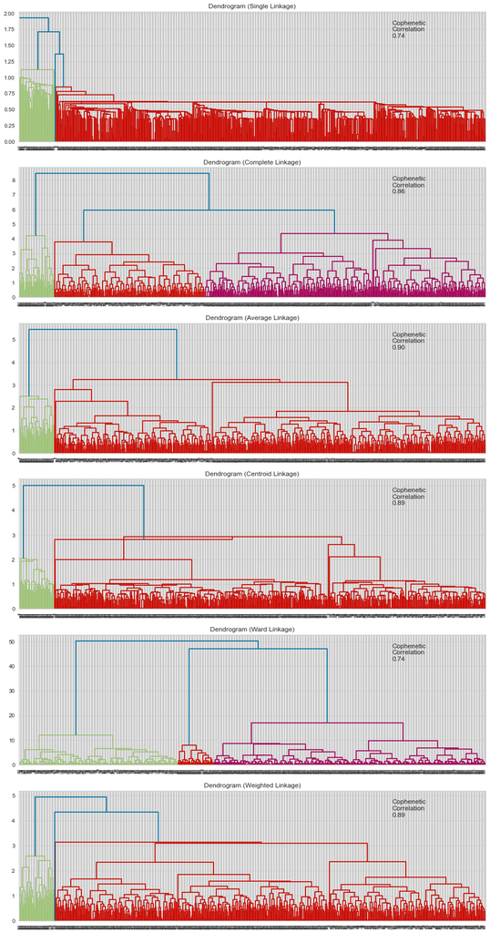

```python
# list of linkage methods
linkage_methods = ["single", "complete", "average", "centroid", "ward", "weighted"]

# lists to save results of cophenetic correlation calculation
compare_cols = ["Linkage", "Cophenetic Coefficient"]

# to create a subplot image
fig, axs = plt.subplots(len(linkage_methods), 1, figsize=(15, 30))

# We will enumerate through the list of linkage methods above
# For each linkage method, we will plot the dendrogram and calculate the cophenetic correlation
for i, method in enumerate(linkage_methods):
    Z = linkage(subset_scaled_df, metric="euclidean", method=method)

    dendrogram(Z, ax=axs[i])
    axs[i].set_title(f"Dendrogram ({method.capitalize()} Linkage)")

    coph_corr, coph_dist = cophenet(Z, pdist(subset_scaled_df))
    axs[i].annotate(
        f"Cophenetic\nCorrelation\n{coph_corr:0.2f}",
        (0.80, 0.80),
        xycoords="axes fraction",
    )
```

**Observations**

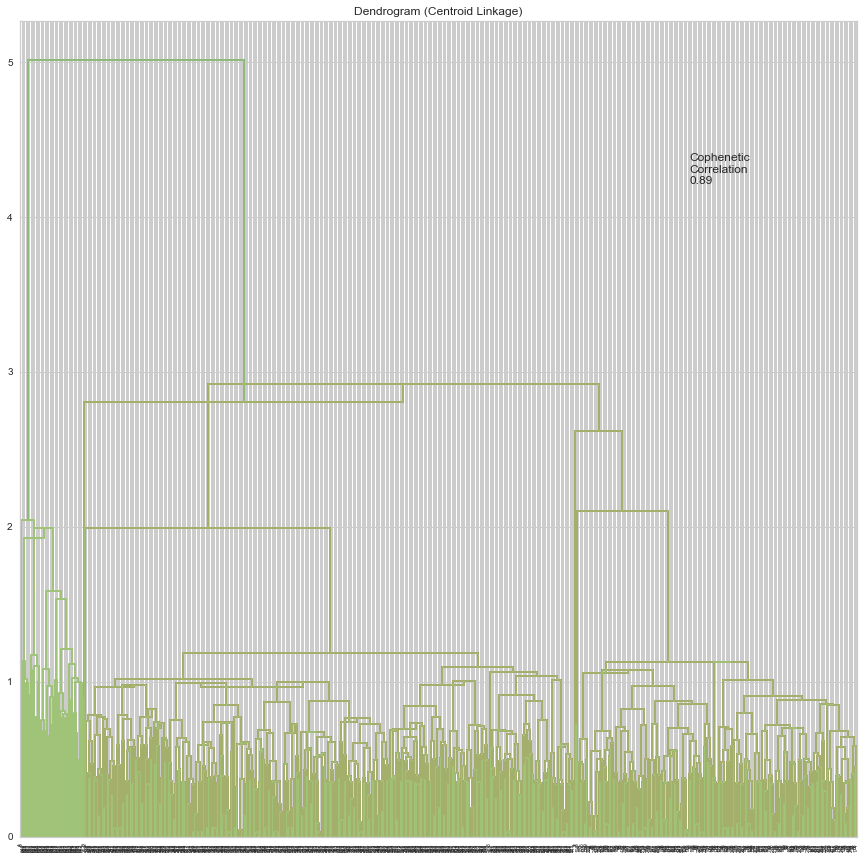

```python
# list of linkage methods
linkage_methods = ["centroid"]

# lists to save results of cophenetic correlation calculation
compare_cols = ["Linkage", "Cophenetic Coefficient"]

# to create a subplot image
fig, axs = plt.subplots(len(linkage_methods), 1, figsize=(15, 15))

# We will enumerate through the list of linkage methods above
# For each linkage method, we will plot the dendrogram and calculate the cophenetic correlation
for i, method in enumerate(linkage_methods):
    Z = linkage(subset_scaled_df, metric="euclidean", method=method)

    dendrogram(Z, ax=axs)
    axs.set_title(f"Dendrogram ({method.capitalize()} Linkage)")

    coph_corr, coph_dist = cophenet(Z, pdist(subset_scaled_df))
    axs.annotate(
        f"Cophenetic\nCorrelation\n{coph_corr:0.2f}",
        (0.80, 0.80),
        xycoords="axes fraction",
    )
dendrogram(Z, color_threshold=7.3)
plt.axhline(y=7.3, c="red", lw=1, linestyle="dashdot")
```

## Hierarchical Clustering

```python
HCmodel = AgglomerativeClustering(n_clusters=3, affinity="euclidean", linkage="average")
HCmodel.fit(subset_scaled_df)
```

```
AgglomerativeClustering(linkage='average', n_clusters=3)
```

```python
subset_scaled_df["HC_Clusters"] = HCmodel.labels_
df1["HC_Clusters"] = HCmodel.labels_
```

## Cluster Profiling

```python
cluster_profile = df1.groupby("HC_Clusters").mean()
```

```python
cluster_profile["count_in_each_segments"] = (
    df1.groupby("HC_Clusters")["Avg_Credit_Limit"].count().values
)
```

```python
# let's see the names of the countries in each cluster
for cl in df1["HC_Clusters"].unique():
    print("In cluster {}, the users with total no of credit cards present:".format(cl))
    print(df1[df1["HC_Clusters"] == cl]["Total_Credit_Cards"].unique())
    print()
```

```
In cluster 0, the users with total no of credit cards present:
[2 7 5 4 6]

In cluster 2, the users with total no of credit cards present:
[3 2 4 1]

In cluster 1, the users with total no of credit cards present:
[ 6  5  9  8 10  7]
```

```python
# lets display cluster profile
cluster_profile.style.highlight_max(color="lightgreen", axis=0)
```

| HC_Clusters | Avg_Credit_Limit | Total_Credit_Cards | Total_visits_bank | Total_visits_online | Total_calls_made | count_in_each_segments |
| --- | --- | --- | --- | --- | --- | --- |
| 0 | 33713.178295 | 5.511628 | 3.485788 | 0.984496 | 2.005168 | 387 |
| 1 | 141040.000000 | 8.740000 | 0.600000 | 10.900000 | 1.080000 | 50 |
| 2 | 12197.309417 | 2.403587 | 0.928251 | 3.560538 | 6.883408 | 223 |

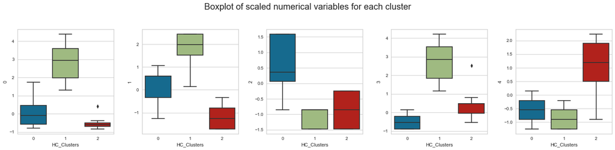

```python
fig, axes = plt.subplots(1,5, figsize=(20, 5),squeeze=False)
fig.suptitle("Boxplot of scaled numerical variables for each cluster", fontsize=20)
counter = 0
for ii in range(1):
    sns.boxplot(
        ax=axes[ii][0],
        y=subset_scaled_df[0],
        x=subset_scaled_df["HC_Clusters"],
    )
    counter = counter + 1
    sns.boxplot(
        ax=axes[ii][1],
        y=subset_scaled_df[1],
        x=subset_scaled_df["HC_Clusters"],
    )
    counter = counter + 1
    sns.boxplot(
        ax=axes[ii][2],
        y=subset_scaled_df[2],
        x=subset_scaled_df["HC_Clusters"],
    )
    counter = counter + 1
    sns.boxplot(
        ax=axes[ii][3],
        y=subset_scaled_df[3],
        x=subset_scaled_df["HC_Clusters"],
    )
    counter = counter + 1
    sns.boxplot(
        ax=axes[ii][4],
        y=subset_scaled_df[4],
        x=subset_scaled_df["HC_Clusters"],
    )
    counter = counter + 1

fig.tight_layout(pad=2.0)
```

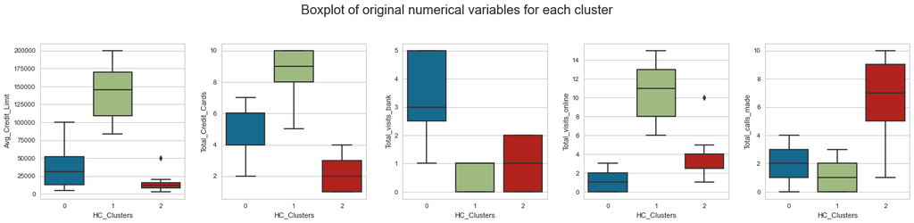

```python
fig, axes = plt.subplots(1,5, figsize=(20, 5),squeeze=False)
fig.suptitle("Boxplot of original numerical variables for each cluster", fontsize=20)
counter = 0
for ii in range(1):
    sns.boxplot(ax=axes[ii][0], y=df1[num_cols[counter]], x=df1["HC_Clusters"])
    counter = counter + 1
    sns.boxplot(ax=axes[ii][1], y=df1[num_cols[counter]], x=df1["HC_Clusters"])
    counter = counter + 1
    sns.boxplot(ax=axes[ii][2], y=df1[num_cols[counter]], x=df1["HC_Clusters"])
    counter = counter + 1
    sns.boxplot(ax=axes[ii][3], y=df1[num_cols[counter]], x=df1["HC_Clusters"])
    counter = counter + 1
    sns.boxplot(ax=axes[ii][4], y=df1[num_cols[counter]], x=df1["HC_Clusters"])
    counter = counter + 1

fig.tight_layout(pad=2.0)
```

## Recommendations

**Cluster 1 seem to be more tech savvy with less issues. Bank need to focus on these customers as they seem to be the main customers.**

## Dimensionality Reduction using PCA for visualization

```python
# importing library
from sklearn.decomposition import PCA

# setting the number of components to 2
pca = PCA(n_components=3)

# transforming data and storing results in a dataframe
X_reduced_pca = pca.fit_transform(subset_scaled_df)
reduced_df_pca = pd.DataFrame(
    data=X_reduced_pca, columns=["Component 1", "Component 2",'Component 3']
)
```

```python
# checking the amount of variance explained
pca.explained_variance_ratio_.sum()
```

```
0.8950105052618708
```

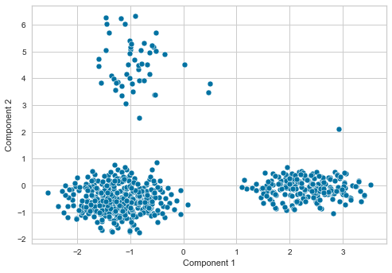

```python
sns.scatterplot(data=reduced_df_pca, x="Component 1", y="Component 2")
```

Let's colour the scatterplot by cluster labels.

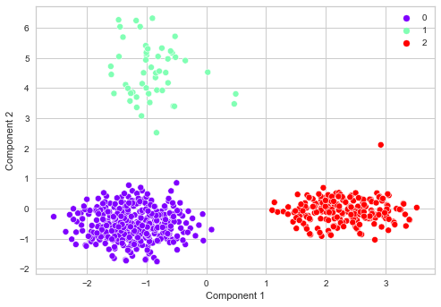

```python
sns.scatterplot(
    data=reduced_df_pca,
    x="Component 1",
    y="Component 2",
    hue=df1["HC_Clusters"],
    palette="rainbow",
)
plt.legend(bbox_to_anchor=(1, 1))
```

- Cluster 0 and 2 are the major clusters with maximum number of customers.

## Comparison vs K-means vs Hierarchical Clustering

- Both have roughly similar distribution in terms of customers divided in 3 clusters.
- Roughly same is conslusion is seem from both. There are 3 types of customers:
  - Customers who are tech savy and have credit limit, more credit cards and uses the bank services online.
  - Second cluster of customers who have less credit limit and make more call/trips to the bank.
  - Another cluster who are in the moderate catergory who also uses less sevrices online but make good trips to bank
- Insights & Business Recommendation are provided for both methods in their respective sections.